# spotify

## ADJUSTING MUSICAL FEATURES RANGE

```python
print(data['explicit'].unique())
```

```
[False  True]
```

```python
data[(data['danceability'] > 1) | (data['danceability'] < 0)]
data[(data['energy']>1)|(data['energy']<0)]
data[(data['acousticness']>1)|(data['acousticness']<0)]
data[(data['valence']>1)|(data['valence']<0)]
data[(data['speechiness']>1)|(data['speechiness']<0)]
data[(data['liveness']>1)|(data['liveness']<0)]
data[(data['instrumentalness']>1)|(data['instrumentalness']<0)]
data[(data['key']>11)|(data['key']<0)]
data[~data['mode'].isin([0, 1])]
data[(data['popularity']>100)|(data['popularity']<0)]
data[(~data['explicit']=="True")|(~data['explicit']=="False")]
```

[output not shown]

```python
data[data['loudness']>0]
```

|  | track_id | artists | album_name | track_name | popularity | duration_ms | explicit | danceability | energy | key | loudness | mode | speechiness | acousticness | instrumentalness | liveness | valence | tempo | time_signature | track_genre |
| --- | --- | --- | --- | --- | --- | --- | --- | --- | --- | --- | --- | --- | --- | --- | --- | --- | --- | --- | --- | --- |
| 5307 | 4KQTgmkSEBzsGS3qL1aX7G | Sayuri | Sorewa Chiisana Hikarinoyouna | それは小さな光のような | 36 | 272916 | False | 0.492 | 0.959 | 7 | 0.698 | 0 | 0.0535 | 0.109000 | 0.000000 | 0.0796 | 0.349 | 143.966 | 3 | anime |
| 5710 | 7FOeR1X65DEG4KjpVhNC4Z | Sayuri | それは小さな光のような-special edition | それは小さな光のような | 52 | 272906 | False | 0.492 | 0.959 | 7 | 0.698 | 0 | 0.0535 | 0.109000 | 0.000000 | 0.0796 | 0.349 | 143.966 | 3 | anime |
| 10033 | 2aRWAz05qiQ9j5HgX7xNHC | Noisia;Burr Oak | The Resonance IV | Stigma - Burr Oak Remix | 32 | 273488 | False | 0.550 | 0.865 | 7 | 0.025 | 1 | 0.0473 | 0.008500 | 0.894000 | 0.4090 | 0.120 | 171.973 | 4 | breakbeat |
| 10137 | 3yqoJ4rc45ep4M0iLa32rC | Dub Pistols;Deekline;Kleu | Ganja | Ganja - Deekline & Kleu Remix | 19 | 270171 | False | 0.790 | 0.973 | 1 | 0.082 | 1 | 0.1470 | 0.030000 | 0.000019 | 0.2620 | 0.759 | 87.474 | 4 | breakbeat |
| 10705 | 5TTJq1w8bLnUHweg924HfI | DJ Fixx | STARS | STARS | 12 | 262500 | False | 0.715 | 0.998 | 10 | 0.202 | 0 | 0.0502 | 0.007750 | 0.254000 | 0.2790 | 0.898 | 127.985 | 4 | breakbeat |
| ... | ... | ... | ... | ... | ... | ... | ... | ... | ... | ... | ... | ... | ... | ... | ... | ... | ... | ... | ... | ... |
| 83904 | 4Y96sBPDQARk39recOzBo9 | Marshmello | Love U | Love U | 41 | 207887 | False | 0.532 | 0.954 | 2 | 0.605 | 0 | 0.0393 | 0.095300 | 0.008280 | 0.2940 | 0.770 | 141.963 | 4 | progressive-house |
| 87512 | 2VQ66m1O2NELSZ5d5a4aMQ | Sergio Vega "El Shaka" | Me Gusta Estar Contigo | El Terrón | 45 | 147520 | False | 0.834 | 0.759 | 8 | 0.681 | 1 | 0.0432 | 0.508000 | 0.000285 | 0.0649 | 0.972 | 95.851 | 3 | r-n-b |
| 109692 | 2cfUY5ppstJHmqdUcFgZ5O | Nosferatu | Demonic Playgrounds | Beat the system | 27 | 228373 | True | 0.719 | 0.992 | 6 | 0.550 | 0 | 0.3660 | 0.280000 | 0.045200 | 0.1300 | 0.118 | 99.977 | 3 | techno |
| 109870 | 3q7eDGLKP0MlhqaGEJ3Lg0 | Cascada;Fallen Superhero | Everytime We Touch (Fallen Superhero Remix) | Everytime We Touch - Fallen Superhero Remix | 53 | 218587 | False | 0.610 | 0.971 | 6 | 0.006 | 0 | 0.1690 | 0.064100 | 0.000004 | 0.3380 | 0.487 | 150.089 | 4 | techno |
| 110166 | 5sqkarfxe7UejHTlCtHCLS | Fear, and Loathing in Las Vegas | Feeling of Unity | Let Me Hear | 61 | 225546 | False | 0.175 | 0.995 | 6 | 1.023 | 0 | 0.2110 | 0.000145 | 0.000003 | 0.2140 | 0.303 | 184.066 | 4 | trance |

90 rows × 20 columns

```python
data['loudness']=data['loudness'].apply(lambda x:-x if x>0 else x)
```

```python
data[data['loudness']<-60]
```

|  | track_id | artists | album_name | track_name | popularity | duration_ms | explicit | danceability | energy | key | loudness | mode | speechiness | acousticness | instrumentalness | liveness | valence | tempo | time_signature | track_genre |
| --- | --- | --- | --- | --- | --- | --- | --- | --- | --- | --- | --- | --- | --- | --- | --- | --- | --- | --- | --- | --- |

```python
data[(data['time_signature']>5)|(data['time_signature']<=0)]
```

|  | track_id | artists | album_name | track_name | popularity | duration_ms | explicit | danceability | energy | key | loudness | mode | speechiness | acousticness | instrumentalness | liveness | valence | tempo | time_signature | track_genre |
| --- | --- | --- | --- | --- | --- | --- | --- | --- | --- | --- | --- | --- | --- | --- | --- | --- | --- | --- | --- | --- |
| 2926 | 0jdfbvSdaWvxfAlD20TtNc | Yaşlı Amca | Akşamüstü | Sanki Yapamadım | 44 | 213198 | False | 0.442 | 0.56700 | 8 | -6.346 | 0 | 0.0516 | 0.238000 | 0.000325 | 0.0852 | 0.639 | 138.616 | 0 | alt-rock |
| 4131 | 59gg6zQhSKGVnkT3hWAY3l | Max Richter;Lang Lang | Voyager - Essential Max Richter | The Departure | 64 | 151506 | False | 0.000 | 0.03620 | 0 | -22.519 | 0 | 0.0000 | 0.994000 | 0.940000 | 0.0958 | 0.000 | 0.000 | 0 | ambient |
| 4379 | 4acmzQsAeMJa5sGFSog7fu | Dario Marianelli;Jack Liebeck;Benjamin Wallfisch | Jane Eyre - Original Motion Picture Soundtrack | The End of Childhood (feat. Jack Liebeck) | 55 | 73266 | False | 0.000 | 0.04450 | 0 | -26.440 | 0 | 0.0000 | 0.972000 | 0.972000 | 0.0873 | 0.000 | 0.000 | 0 | ambient |
| 4664 | 1Kb2DqjHRvOcT5xeWtz3t5 | Sylvain Chauveau | Des Plumes Dans La Tête | Ferme Les Yeux | 53 | 68493 | False | 0.000 | 0.03230 | 2 | -23.636 | 0 | 0.0000 | 0.994000 | 0.973000 | 0.0922 | 0.000 | 0.000 | 0 | ambient |
| 26910 | 7HSc2wpHlXKIl8SCZK7zsP | Benny Martin | Here Comes the Sun (Piano Instrumental) | Here Comes the Sun (Piano Instrumental) | 18 | 203705 | False | 0.329 | 0.06070 | 9 | -28.310 | 1 | 0.0507 | 0.994000 | 0.880000 | 0.0858 | 0.421 | 93.948 | 0 | disney |
| ... | ... | ... | ... | ... | ... | ... | ... | ... | ... | ... | ... | ... | ... | ... | ... | ... | ... | ... | ... | ... |
| 101993 | 6H0kAiSAFB84jX7dgEDWd6 | Rain Sounds | Rain | Rain: Natural Recording | 32 | 84219 | False | 0.000 | 0.02540 | 8 | -19.925 | 1 | 0.0000 | 0.000002 | 0.838000 | 0.3390 | 0.000 | 0.000 | 0 | sleep |
| 112172 | 0jdfbvSdaWvxfAlD20TtNc | Yaşlı Amca | Akşamüstü | Sanki Yapamadım | 44 | 213198 | False | 0.442 | 0.56700 | 8 | -6.346 | 0 | 0.0516 | 0.238000 | 0.000325 | 0.0852 | 0.639 | 138.616 | 0 | turkish |
| 113428 | 5EYzrykQ95uOmepteDi9KT | El Ruido Blanco;Soñoliento Juan;Mantra para Do... | Aire Acondicionado de Ruido Blanco | Aire de verano | 27 | 128000 | False | 0.000 | 0.18800 | 8 | -25.837 | 0 | 0.0000 | 0.139000 | 0.339000 | 0.1220 | 0.000 | 0.000 | 0 | world-music |
| 113688 | 2EnZf7wbFv7ST4CJ3EvNzT | El Ruido Blanco | Ruido Blanco para el bebé: sonidos relajantes ... | Ruido Rosa Puro - Una Hora Versión | 24 | 3601693 | False | 0.000 | 0.00002 | 1 | -11.165 | 1 | 0.0000 | 0.186000 | 1.000000 | 0.3620 | 0.000 | 0.000 | 0 | world-music |
| 113856 | 6XsYJ0dwT2hRzp0Qles78F | Колыбельная-земля | Расслабляющие звуки - белый шум для вашего реб... | Пылесос (Белый шум) | 22 | 302185 | False | 0.000 | 0.22400 | 8 | -10.224 | 1 | 0.0000 | 0.142000 | 0.986000 | 0.4110 | 0.000 | 0.000 | 0 | world-music |

163 rows × 20 columns

```python
data['time_signature'].unique()
```

```
array([4, 3, 1, 5, 0], dtype=int64)
```

```python
data['time_signature']=data['time_signature'].apply(lambda x:2 if x==0 else x)
data['time_signature'].unique()
```

```
array([4, 3, 1, 5, 2], dtype=int64)
```

## Duration into categories

```python
import numpy as np
np.quantile(data['duration_ms'],[0.25,0.75])
```

```
array([174066., 261506.])
```

```python
def classify_song_duration(duration_ms):
    if duration_ms<174066:
        return "Short"
    elif duration_ms<261506:
        return "Medium"
    else:
        return "Long"
data['Duration_Category']=data['duration_ms'].apply( classify_song_duration)
data.head()
```

|  | track_id | artists | album_name | track_name | popularity | duration_ms | explicit | danceability | energy | key | ... | mode | speechiness | acousticness | instrumentalness | liveness | valence | tempo | time_signature | track_genre | Duration_Category |
| --- | --- | --- | --- | --- | --- | --- | --- | --- | --- | --- | --- | --- | --- | --- | --- | --- | --- | --- | --- | --- | --- |
| 0 | 5SuOikwiRyPMVoIQDJUgSV | Gen Hoshino | Comedy | Comedy | 73 | 230666 | False | 0.676 | 0.4610 | 1 | ... | 0 | 0.1430 | 0.0322 | 0.000001 | 0.3580 | 0.715 | 87.917 | 4 | acoustic | Medium |
| 1 | 4qPNDBW1i3p13qLCt0Ki3A | Ben Woodward | Ghost (Acoustic) | Ghost - Acoustic | 55 | 149610 | False | 0.420 | 0.1660 | 1 | ... | 1 | 0.0763 | 0.9240 | 0.000006 | 0.1010 | 0.267 | 77.489 | 4 | acoustic | Short |
| 2 | 1iJBSr7s7jYXzM8EGcbK5b | Ingrid Michaelson;ZAYN | To Begin Again | To Begin Again | 57 | 210826 | False | 0.438 | 0.3590 | 0 | ... | 1 | 0.0557 | 0.2100 | 0.000000 | 0.1170 | 0.120 | 76.332 | 4 | acoustic | Medium |
| 3 | 6lfxq3CG4xtTiEg7opyCyx | Kina Grannis | Crazy Rich Asians (Original Motion Picture Sou... | Can't Help Falling In Love | 71 | 201933 | False | 0.266 | 0.0596 | 0 | ... | 1 | 0.0363 | 0.9050 | 0.000071 | 0.1320 | 0.143 | 181.740 | 3 | acoustic | Medium |
| 4 | 5vjLSffimiIP26QG5WcN2K | Chord Overstreet | Hold On | Hold On | 82 | 198853 | False | 0.618 | 0.4430 | 2 | ... | 1 | 0.0526 | 0.4690 | 0.000000 | 0.0829 | 0.167 | 119.949 | 4 | acoustic | Medium |

5 rows × 21 columns

## Popularity into categories

```python
def classify_popularity(popularity):
    if popularity<25:
        return "Unpopular"
    elif popularity<50:
        return "Moderately popular"
    elif popularity<75:
        return "Popular"
    else:
        return "Viral"
data['Popularity_Categorized']=data['popularity'].apply( classify_popularity)
data.head()
```

|  | track_id | artists | album_name | track_name | popularity | duration_ms | explicit | danceability | energy | key | ... | speechiness | acousticness | instrumentalness | liveness | valence | tempo | time_signature | track_genre | Duration_Category | Popularity_Categorized |
| --- | --- | --- | --- | --- | --- | --- | --- | --- | --- | --- | --- | --- | --- | --- | --- | --- | --- | --- | --- | --- | --- |
| 0 | 5SuOikwiRyPMVoIQDJUgSV | Gen Hoshino | Comedy | Comedy | 73 | 230666 | False | 0.676 | 0.4610 | 1 | ... | 0.1430 | 0.0322 | 0.000001 | 0.3580 | 0.715 | 87.917 | 4 | acoustic | Medium | Popular |
| 1 | 4qPNDBW1i3p13qLCt0Ki3A | Ben Woodward | Ghost (Acoustic) | Ghost - Acoustic | 55 | 149610 | False | 0.420 | 0.1660 | 1 | ... | 0.0763 | 0.9240 | 0.000006 | 0.1010 | 0.267 | 77.489 | 4 | acoustic | Short | Popular |
| 2 | 1iJBSr7s7jYXzM8EGcbK5b | Ingrid Michaelson;ZAYN | To Begin Again | To Begin Again | 57 | 210826 | False | 0.438 | 0.3590 | 0 | ... | 0.0557 | 0.2100 | 0.000000 | 0.1170 | 0.120 | 76.332 | 4 | acoustic | Medium | Popular |
| 3 | 6lfxq3CG4xtTiEg7opyCyx | Kina Grannis | Crazy Rich Asians (Original Motion Picture Sou... | Can't Help Falling In Love | 71 | 201933 | False | 0.266 | 0.0596 | 0 | ... | 0.0363 | 0.9050 | 0.000071 | 0.1320 | 0.143 | 181.740 | 3 | acoustic | Medium | Popular |
| 4 | 5vjLSffimiIP26QG5WcN2K | Chord Overstreet | Hold On | Hold On | 82 | 198853 | False | 0.618 | 0.4430 | 2 | ... | 0.0526 | 0.4690 | 0.000000 | 0.0829 | 0.167 | 119.949 | 4 | acoustic | Medium | Viral |

5 rows × 22 columns

## Remove Duplicate Rows

```python
data.duplicated().sum()
```

```
450
```

```python
data.drop_duplicates(inplace=True)
```

```python
data.duplicated().sum()
```

```
0
```

```python
data.describe()
```

|  | popularity | duration_ms | danceability | energy | key | loudness | mode | speechiness | acousticness | instrumentalness | liveness | valence | tempo | time_signature |
| --- | --- | --- | --- | --- | --- | --- | --- | --- | --- | --- | --- | --- | --- | --- |
| count | 113549.000000 | 1.135490e+05 | 113549.000000 | 113549.000000 | 113549.000000 | 113549.000000 | 113549.000000 | 113549.000000 | 113549.000000 | 113549.000000 | 113549.000000 | 113549.000000 | 113549.000000 | 113549.000000 |
| mean | 33.324433 | 2.280814e+05 | 0.567031 | 0.642091 | 5.309452 | -8.244494 | 0.637866 | 0.084674 | 0.314064 | 0.155703 | 0.213613 | 0.474205 | 122.175745 | 3.907089 |
| std | 22.283855 | 1.064131e+05 | 0.173409 | 0.251053 | 3.560147 | 5.009634 | 0.480620 | 0.105762 | 0.331906 | 0.309217 | 0.190462 | 0.259204 | 29.972954 | 0.412360 |
| min | 0.000000 | 8.586000e+03 | 0.000000 | 0.000000 | 0.000000 | -49.531000 | 0.000000 | 0.000000 | 0.000000 | 0.000000 | 0.000000 | 0.000000 | 0.000000 | 1.000000 |
| 25% | 17.000000 | 1.741840e+05 | 0.456000 | 0.473000 | 2.000000 | -9.998000 | 0.000000 | 0.035900 | 0.016800 | 0.000000 | 0.098000 | 0.260000 | 99.296000 | 4.000000 |
| 50% | 35.000000 | 2.130000e+05 | 0.580000 | 0.685000 | 5.000000 | -6.997000 | 1.000000 | 0.048900 | 0.168000 | 0.000041 | 0.132000 | 0.464000 | 122.020000 | 4.000000 |
| 75% | 50.000000 | 2.615880e+05 | 0.695000 | 0.854000 | 8.000000 | -5.001000 | 1.000000 | 0.084500 | 0.596000 | 0.048700 | 0.273000 | 0.683000 | 140.074000 | 4.000000 |
| max | 100.000000 | 5.237295e+06 | 0.985000 | 1.000000 | 11.000000 | -0.001000 | 1.000000 | 0.965000 | 0.996000 | 1.000000 | 1.000000 | 0.995000 | 243.372000 | 5.000000 |

## LABEL ENCODING

```python
filtered_data=data.drop(columns=['track_id','artists','album_name','track_name','track_genre'])
from sklearn.preprocessing import LabelEncoder
label_enc=LabelEncoder()
filtered_data['explicit']=label_enc.fit_transform(data['explicit'])
filtered_data['Duration_Category']=label_enc.fit_transform(data['Duration_Category'])
label_map={
    label_enc.transform(['Short'])[0]:0,
    label_enc.transform(['Medium'])[0]:1,
    label_enc.transform(['Long'])[0]:2
}
filtered_data['Popularity_Categorized']=label_enc.fit_transform(data['Popularity_Categorized'])
label_map={
    label_enc.transform(['Unpopular'])[0]:0,
    label_enc.transform(['Moderately popular'])[0]:1,
    label_enc.transform(['Popular'])[0]:2,
    label_enc.transform(['Viral'])[0]:3
}
filtered_data.head()
```

|  | popularity | duration_ms | explicit | danceability | energy | key | loudness | mode | speechiness | acousticness | instrumentalness | liveness | valence | tempo | time_signature | Duration_Category | Popularity_Categorized |
| --- | --- | --- | --- | --- | --- | --- | --- | --- | --- | --- | --- | --- | --- | --- | --- | --- | --- |
| 0 | 73 | 230666 | 0 | 0.676 | 0.4610 | 1 | -6.746 | 0 | 0.1430 | 0.0322 | 0.000001 | 0.3580 | 0.715 | 87.917 | 4 | 1 | 1 |
| 1 | 55 | 149610 | 0 | 0.420 | 0.1660 | 1 | -17.235 | 1 | 0.0763 | 0.9240 | 0.000006 | 0.1010 | 0.267 | 77.489 | 4 | 2 | 1 |
| 2 | 57 | 210826 | 0 | 0.438 | 0.3590 | 0 | -9.734 | 1 | 0.0557 | 0.2100 | 0.000000 | 0.1170 | 0.120 | 76.332 | 4 | 1 | 1 |
| 3 | 71 | 201933 | 0 | 0.266 | 0.0596 | 0 | -18.515 | 1 | 0.0363 | 0.9050 | 0.000071 | 0.1320 | 0.143 | 181.740 | 3 | 1 | 1 |
| 4 | 82 | 198853 | 0 | 0.618 | 0.4430 | 2 | -9.681 | 1 | 0.0526 | 0.4690 | 0.000000 | 0.0829 | 0.167 | 119.949 | 4 | 1 | 3 |

## CORRELATION

```python
filtered_data.corr()
```

|  | popularity | duration_ms | explicit | danceability | energy | key | loudness | mode | speechiness | acousticness | instrumentalness | liveness | valence | tempo | time_signature | Duration_Category | Popularity_Categorized |
| --- | --- | --- | --- | --- | --- | --- | --- | --- | --- | --- | --- | --- | --- | --- | --- | --- | --- |
| popularity | 1.000000 | -0.007928 | 0.043938 | 0.034407 | -0.002447 | -0.004167 | 0.047404 | -0.015009 | -0.045463 | -0.022356 | -0.094718 | -0.005668 | -0.041097 | 0.012187 | 0.033172 | -0.025183 | -0.404562 |
| duration_ms | -0.007928 | 1.000000 | -0.066005 | -0.074117 | 0.058160 | 0.008519 | -0.004165 | -0.035961 | -0.063194 | -0.103676 | 0.125301 | 0.010199 | -0.154795 | 0.024312 | 0.015642 | -0.683309 | -0.021666 |
| explicit | 0.043938 | -0.066005 | 1.000000 | 0.122179 | 0.096256 | 0.004843 | 0.107936 | -0.037387 | 0.307455 | -0.093748 | -0.103169 | 0.032367 | -0.003779 | -0.003097 | 0.037936 | 0.081794 | 0.035538 |
| danceability | 0.034407 | -0.074117 | 0.122179 | 1.000000 | 0.131694 | 0.036546 | 0.256773 | -0.069783 | 0.108236 | -0.169181 | -0.183974 | -0.131651 | 0.476755 | -0.051517 | 0.195151 | 0.087003 | 0.008119 |
| energy | -0.002447 | 0.058160 | 0.096256 | 0.131694 | 1.000000 | 0.048047 | 0.760641 | -0.079331 | 0.141976 | -0.732747 | -0.179967 | 0.184810 | 0.258451 | 0.247361 | 0.181482 | -0.110794 | -0.003959 |
| key | -0.004167 | 0.008519 | 0.004843 | 0.036546 | 0.048047 | 1.000000 | 0.038435 | -0.135871 | 0.020820 | -0.041124 | -0.006819 | -0.001518 | 0.034233 | 0.010903 | 0.015746 | -0.010079 | 0.004446 |
| loudness | 0.047404 | -0.004165 | 0.107936 | 0.256773 | 0.760641 | 0.038435 | 1.000000 | -0.042001 | 0.059870 | -0.588196 | -0.432330 | 0.076702 | 0.279619 | 0.212086 | 0.182050 | -0.060275 | -0.012574 |
| mode | -0.015009 | -0.035961 | -0.037387 | -0.069783 | -0.079331 | -0.135871 | -0.042001 | 1.000000 | -0.046773 | 0.096548 | -0.050787 | 0.013900 | 0.021411 | 0.000371 | -0.024908 | 0.039994 | -0.019704 |
| speechiness | -0.045463 | -0.063194 | 0.307455 | 0.108236 | 0.141976 | 0.020820 | 0.059870 | -0.046773 | 1.000000 | -0.001378 | -0.089214 | 0.205092 | 0.036393 | 0.017167 | -0.005845 | 0.091504 | 0.048579 |
| acousticness | -0.022356 | -0.103676 | -0.093748 | -0.169181 | -0.732747 | -0.041124 | -0.588196 | 0.096548 | -0.001378 | 1.000000 | 0.102134 | -0.020313 | -0.106240 | -0.207620 | -0.180139 | 0.151841 | -0.028679 |
| instrumentalness | -0.094718 | 0.125301 | -0.103169 | -0.183974 | -0.179967 | -0.006819 | -0.432330 | -0.050787 | -0.089214 | 0.102134 | 1.000000 | -0.079847 | -0.324314 | -0.049939 | -0.075028 | -0.067249 | 0.062212 |
| liveness | -0.005668 | 0.010199 | 0.032367 | -0.131651 | 0.184810 | -0.001518 | 0.076702 | 0.013900 | 0.205092 | -0.020313 | -0.079847 | 1.000000 | 0.019339 | 0.000547 | -0.016718 | -0.006218 | -0.076261 |
| valence | -0.041097 | -0.154795 | -0.003779 | 0.476755 | 0.258451 | 0.034233 | 0.279619 | 0.021411 | 0.036393 | -0.106240 | -0.324314 | 0.019339 | 1.000000 | 0.077640 | 0.127832 | 0.165163 | -0.013739 |
| tempo | 0.012187 | 0.024312 | -0.003097 | -0.051517 | 0.247361 | 0.010903 | 0.212086 | 0.000371 | 0.017167 | -0.207620 | -0.049939 | 0.000547 | 0.077640 | 1.000000 | 0.042760 | -0.043257 | -0.026350 |
| time_signature | 0.033172 | 0.015642 | 0.037936 | 0.195151 | 0.181482 | 0.015746 | 0.182050 | -0.024908 | -0.005845 | -0.180139 | -0.075028 | -0.016718 | 0.127832 | 0.042760 | 1.000000 | -0.029589 | -0.017474 |
| Duration_Category | -0.025183 | -0.683309 | 0.081794 | 0.087003 | -0.110794 | -0.010079 | -0.060275 | 0.039994 | 0.091504 | 0.151841 | -0.067249 | -0.006218 | 0.165163 | -0.043257 | -0.029589 | 1.000000 | 0.043653 |
| Popularity_Categorized | -0.404562 | -0.021666 | 0.035538 | 0.008119 | -0.003959 | 0.004446 | -0.012574 | -0.019704 | 0.048579 | -0.028679 | 0.062212 | -0.076261 | -0.013739 | -0.026350 | -0.017474 | 0.043653 | 1.000000 |

# EDA

```python
import pandas as pd
import matplotlib.pyplot as plt
import seaborn as sns
```

## Song Length Category Distribution

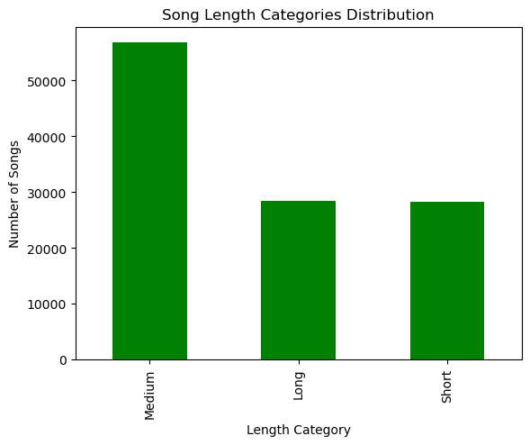

```python
data['Duration_Category'].value_counts().plot(kind='bar', color='green')
plt.title('Song Length Categories Distribution')
plt.xlabel('Length Category')
plt.ylabel('Number of Songs')
plt.show()
```

## POPULARITY CATEGORY DISTRIBUTION

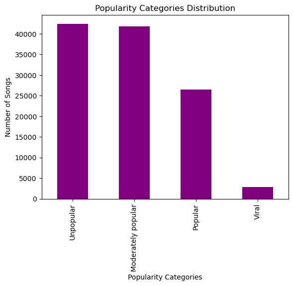

```python
data['Popularity_Categorized'].value_counts().plot(kind='bar', color='purple')
plt.title('Popularity Categories Distribution')
plt.xlabel('Popularity Categories')
plt.ylabel('Number of Songs')
plt.show()
```

### **Inference** :High popularity is rare, which might affect model performance due to the dataset’s imbalance.

## EXPLICIT SONGS DISTRIBUTION

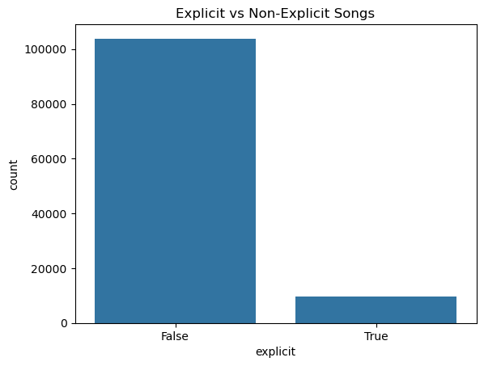

```python
sns.countplot(x='explicit', data=data)
plt.title("Explicit vs Non-Explicit Songs")
plt.show()
```

## Popularity Histogram

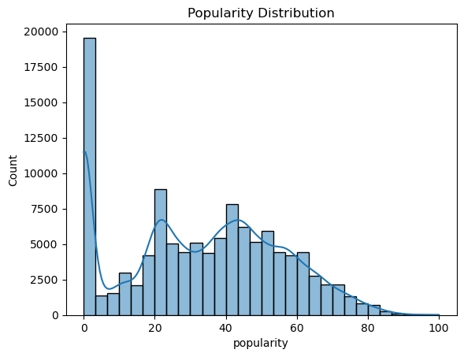

```python
sns.histplot(data['popularity'], bins=30, kde=True)
plt.title("Popularity Distribution")
plt.show()
```

### **Inference** :Highly right skewed.Most songs in the dataset are relatively unknown or less popular

## Energy Histogram

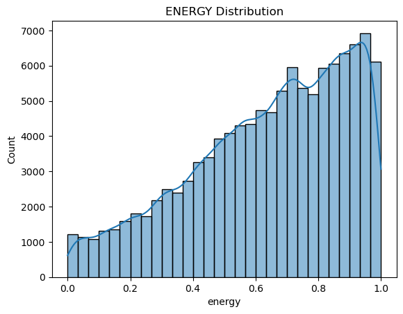

```python
sns.histplot(data['energy'], bins=30,kde=True)
plt.title("ENERGY Distribution")
plt.show()
```

### PIE CHART FOR KEYS

```python
key_counts=data['key'].value_counts().sort_index()
key_counts
```

```
key
0     13006
1     10740
2     11594
3      3548
4      8971
5      9325
6      7891
7     13199
8      7337
9     11264
10     7423
11     9251
Name: count, dtype: int64
```

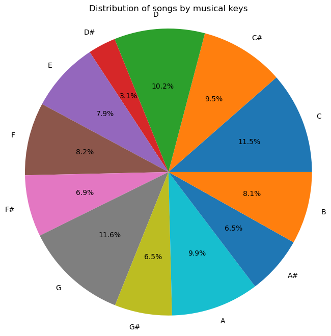

```python
key_labels=['C','C#','D','D#','E','F','F#','G','G#','A','A#','B']
plt.figure(figsize=(8,8))
plt.pie(key_counts,labels=[key_labels[int(i)] for i in key_counts.index],autopct='%1.1f%%')
plt.title("Distribution of songs by musical keys")
plt.axis('equal')
plt.show()
```

## CORRELATION HEATMAP

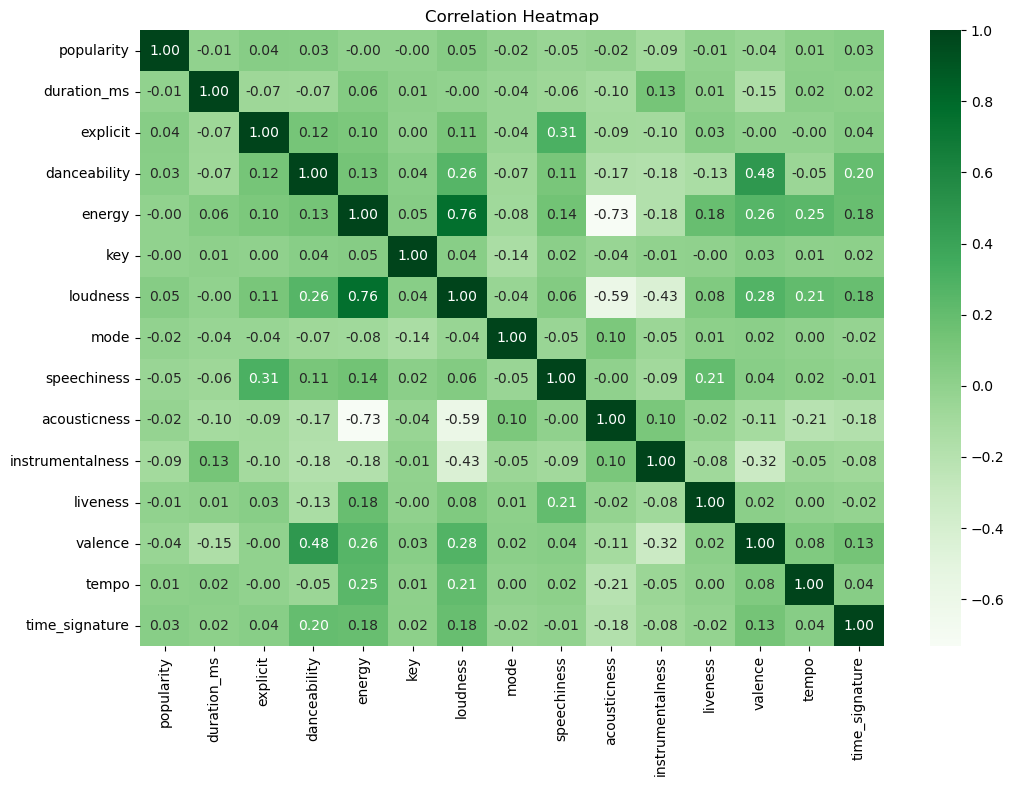

```python
plt.figure(figsize=(12, 8))
sns.heatmap(data.corr(numeric_only=True), annot=True, fmt='.2f', cmap='Greens')
plt.title("Correlation Heatmap")
plt.show()
```

### **Inference** : Energy and acousticness is negatively correlated & Loudness and energy is positively correlated.

## POPULARITY VS ENERGY LEVELS

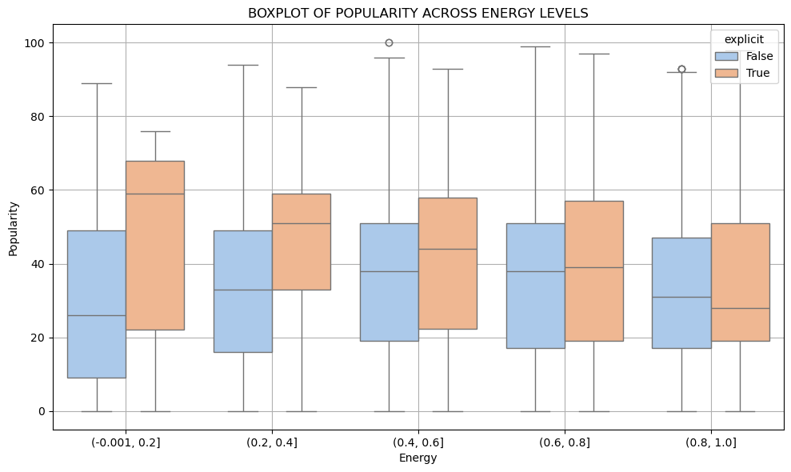

```python
data['energy_bin']=pd.cut(data['energy'],bins=5)
plt.figure(figsize=(10,6))
sns.boxplot(x='energy_bin',y='popularity',data=data,palette='pastel',hue='explicit')
plt.title("BOXPLOT OF POPULARITY ACROSS ENERGY LEVELS")
plt.xlabel("Energy")
plt.ylabel("Popularity")
plt.grid(True)
plt.tight_layout()
```

### **Inference** :Lower energy bins have wider spread in popularity,Especially for explicit songs,As energy increases median popularity decrease for explicit songs.

## ACOUSTICNESS VS ENERGY

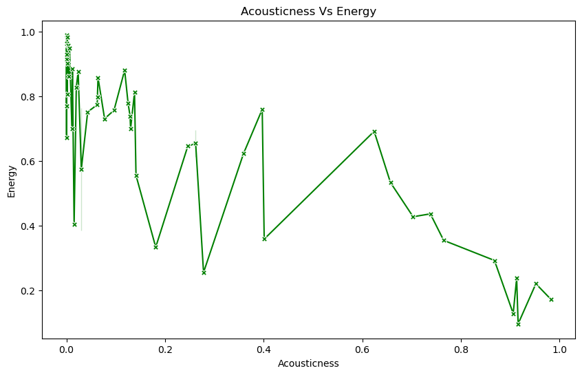

```python
plt.figure(figsize=(10,6))
sns.lineplot(data=data.sample(50),x='acousticness',y='energy',marker="X",color="green")
plt.title("Acousticness Vs Energy")
plt.xlabel("Acousticness")
plt.ylabel("Energy")
plt.show()
```

### **Inference** :Acousticness and energy is negatively correlated but correlation is not linear.

## DANCEABILITY VS POPULARITY

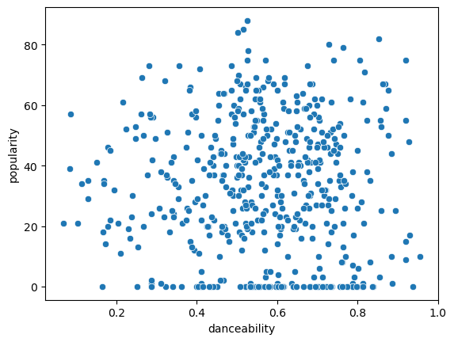

```python
sns.scatterplot(x='danceability',y='popularity',data=data.sample(500))
```

### **Inference** :There is no any correlation between danceability and popularity.

## LOUDNESS VS ENERGY

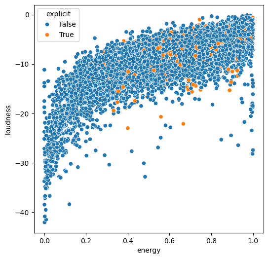

```python
plt.figure(figsize=(6,6))
sns.scatterplot(x='energy',y='loudness',hue='explicit',data=data.sample(10000))
```

### **Inference** :The plot of loudness vs. energy shows a positive correlation, but not in a linear fashion.

```python
unique_cases=data[(data['energy']>0.7)&(data['loudness']<-20)]
unique_cases
```

|  | track_id | artists | album_name | track_name | popularity | duration_ms | explicit | danceability | energy | key | ... | acousticness | instrumentalness | liveness | valence | tempo | time_signature | track_genre | Duration_Category | Popularity_Categorized | energy_bin |
| --- | --- | --- | --- | --- | --- | --- | --- | --- | --- | --- | --- | --- | --- | --- | --- | --- | --- | --- | --- | --- | --- |
| 6505 | 790GAji6LuoHsHswTGKlbY | Arckanum | Kostogher | Yvir Min Diupe Marder | 18 | 283706 | False | 0.2080 | 0.970 | 1 | ... | 0.00000 | 0.951000 | 0.0962 | 0.03680 | 149.261 | 4 | black-metal | Long | Unpopular | (0.8, 1.0] |
| 18133 | 4gUw5pJgAAAQMzq80LnPye | Sebastian Maniscalco | Sebastian LIVE | Showering Is An Event | 26 | 297755 | True | 0.3600 | 0.799 | 4 | ... | 0.84000 | 0.000167 | 0.8880 | 0.12700 | 85.036 | 4 | comedy | Long | Moderately popular | (0.6, 0.8] |
| 18278 | 3gqDcHFH3r5AQzsr3r6g0L | Sebastian Maniscalco | Sebastian LIVE | All Starts on the First Date | 24 | 391557 | True | 0.3650 | 0.728 | 2 | ... | 0.81400 | 0.000004 | 0.9300 | 0.19600 | 66.737 | 3 | comedy | Long | Unpopular | (0.6, 0.8] |
| 24418 | 42WTV9wf8twiHEiX6YLGRL | Theo Parrish;Marcellus Pittman | Essential Selections Volume 2 | Equality Of Patience - Short | 8 | 324226 | False | 0.7910 | 0.758 | 1 | ... | 0.00221 | 0.914000 | 0.1870 | 0.89000 | 107.736 | 4 | detroit-techno | Long | Unpopular | (0.6, 0.8] |
| 101013 | 2OkrxnSE2OG0bOGjniOCl6 | Silent Knights | Sleepy Baby Womb Sounds | Womb Heartbeat (No Fade for Looping) | 57 | 55401 | False | 0.3990 | 0.897 | 10 | ... | 0.94600 | 0.942000 | 0.1110 | 0.03750 | 178.746 | 3 | sleep | Short | Popular | (0.8, 1.0] |
| ... | ... | ... | ... | ... | ... | ... | ... | ... | ... | ... | ... | ... | ... | ... | ... | ... | ... | ... | ... | ... | ... |
| 113831 | 7q8xQK3L1z3Vt9El830B6O | Relajación océano y olas | Sonido de las Olas del Mar para Relajarse | Sonido de las Olas del Mar para Relajarse, Pt. 11 | 22 | 108570 | False | 0.1830 | 0.823 | 2 | ... | 0.54300 | 0.920000 | 0.9210 | 0.00766 | 83.046 | 4 | world-music | Short | Unpopular | (0.8, 1.0] |
| 113916 | 6ul5bvsJ2Z59kC62nzrmrP | Ruido Blanco Hart;Ondas Alfa;Música de concent... | Chispa Encendida: Flujo De Antorchas | La Calidez Sana Del Agua | 21 | 120000 | False | 0.2290 | 0.986 | 10 | ... | 0.10300 | 0.042700 | 0.7160 | 0.01480 | 112.275 | 3 | world-music | Short | Unpopular | (0.8, 1.0] |
| 113935 | 6aqfqfzU1GjtKQb3ujUMGb | Reiki Armonía | Sonidos de Fondo para Reiki: Gotas de Agua | Para Reiki: Gotas de Agua, Pt. 17 | 22 | 112198 | False | 0.1180 | 0.927 | 10 | ... | 0.15400 | 0.985000 | 0.8930 | 0.00398 | 150.370 | 5 | world-music | Short | Unpopular | (0.8, 1.0] |
| 113940 | 3Fj6wu6AAnltIyS2jNbqiG | Flor de Loto | 25 Canciones de la Naturaleza - Sonidos de la ... | Hermosa Daydream (Música Tranquila y Pacífica) | 22 | 289999 | False | 0.0565 | 0.995 | 2 | ... | 0.86700 | 0.000419 | 0.6830 | 0.01010 | 53.465 | 3 | world-music | Long | Unpopular | (0.8, 1.0] |
| 113979 | 5wMkhfu3oYYmFimOGzeFt2 | Fondo de la lectura | Concentración: Sonidos de la Lluvia | Concentración: Sonidos de la Lluvia, Pt. 01 | 22 | 143403 | False | 0.4170 | 0.967 | 5 | ... | 0.92400 | 0.958000 | 0.6960 | 0.01470 | 65.002 | 4 | world-music | Short | Unpopular | (0.8, 1.0] |

118 rows × 23 columns

```python
unique_cases['track_genre'].value_counts()
```

```
track_genre
sleep             99
world-music       15
comedy             2
black-metal        1
detroit-techno     1
Name: count, dtype: int64
```

```python
unique_cases['popularity'].describe()
```

```
count    118.000000
mean      29.271186
std       13.949641
min        0.000000
25%       24.250000
50%       34.000000
75%       36.000000
max       60.000000
Name: popularity, dtype: float64
```

#### **Inference** :Some unique cases exhibit higher energy and lower loudness, mostly from the "Sleep" genre. This suggests that certain genres, like "Sleep," may feature songs with atypical energy-loudness patterns.

## OUTLIER ANALYSIS OF SPEECHINESS AND TEMPO

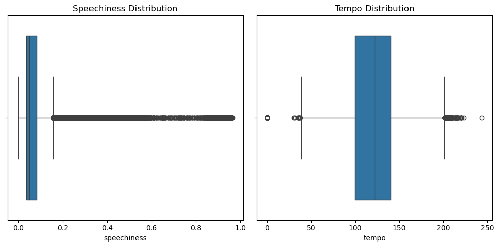

```python
fig,axes=plt.subplots(1,2,figsize=(10,5))
sns.boxplot(ax=axes[0],x=data['speechiness'])
axes[0].set_title("Speechiness Distribution")

sns.boxplot(ax=axes[1],x=data['tempo'])
axes[1].set_title("Tempo Distribution")
plt.tight_layout()
plt.show()
```

```python
print("median",data['speechiness'].median())
speechiness_q1 = data['speechiness'].quantile(0.25)
speechiness_q3 = data['speechiness'].quantile(0.75)
speechiness_iqr = speechiness_q3 - speechiness_q1
print("Q1",speechiness_q1)
print("Q2",speechiness_q3)
print("IQR",speechiness_iqr)
speechiness_lower_bound = speechiness_q1 - 1.5 * speechiness_iqr
speechiness_upper_bound = speechiness_q3 + 1.5 * speechiness_iqr
print("Outlier thresholds:", speechiness_lower_bound, "to", speechiness_upper_bound)
```

```
median 0.0489
Q1 0.0359
Q2 0.0845
IQR 0.048600000000000004
Outlier thresholds: -0.037000000000000005 to 0.1574
```

```python
speechiness_outliers = data[data['speechiness'] > speechiness_upper_bound]
print("Number of Speechiness Upper outliers:", len(speechiness_outliers))

speech_out_df=speechiness_outliers[[ 'tempo', 'artists', 'track_genre','explicit']]
speech_out_df['track_genre'].value_counts()
```

```
Number of Speechiness Upper outliers: 13167
```

```
track_genre
comedy        885
j-dance       612
dancehall     495
hardcore      365
kids          348
             ...
cantopop       10
mandopop        9
acoustic        6
ambient         5
honky-tonk      2
Name: count, Length: 114, dtype: int64
```

```python
print("median",data['tempo'].median())
tempo_q1 = data['tempo'].quantile(0.25)
tempo_q3 = data['tempo'].quantile(0.75)
tempo_iqr = tempo_q3 - tempo_q1
print("q1",tempo_q1)
print("q3",tempo_q3)
print("iqr",tempo_iqr)
tempo_lower_bound = tempo_q1 - 1.5 * tempo_iqr
tempo_upper_bound = tempo_q3 + 1.5 * tempo_iqr
print( tempo_lower_bound, "to", tempo_upper_bound)
```

```
median 122.02
q1 99.296
q3 140.074
iqr 40.778000000000006
38.129 to 201.241
```

```python
tempo_outliers = data[(data['tempo'] < tempo_lower_bound) | (data['tempo'] > tempo_upper_bound)]
print("Number of tempo outliers:", len(tempo_outliers))
tempo_out_low=data[(data['tempo'] < tempo_lower_bound)]
```

```
Number of tempo outliers: 615
```

```python
print("Number of tempo lower outliers:", len(tempo_out_low))
tempo_out_upp=data[(data['tempo'] >tempo_upper_bound)]
print("Number of tempo upper outliers:", len(tempo_out_upp))
```

```
Number of tempo lower outliers: 170
Number of tempo upper outliers: 445
```

```python
tempo_out_low_df=tempo_out_low[[ 'tempo', 'artists', 'track_genre']]
tempo_out_upp_df=tempo_out_upp[[ 'tempo', 'artists', 'track_genre']]
tempo_out_low_df.head()
```

|  | tempo | artists | track_genre |
| --- | --- | --- | --- |
| 4131 | 0.000 | Max Richter;Lang Lang | ambient |
| 4379 | 0.000 | Dario Marianelli;Jack Liebeck;Benjamin Wallfisch | ambient |
| 4664 | 0.000 | Sylvain Chauveau | ambient |
| 16817 | 35.928 | Wolfgang Amadeus Mozart;Danielle Laval | classical |
| 18417 | 35.392 | Mike Epps | comedy |

```python
tempo_out_upp_df.head()
```

|  | tempo | artists | track_genre |
| --- | --- | --- | --- |
| 32 | 202.019 | Chord Overstreet | acoustic |
| 384 | 204.961 | Boyce Avenue;Kina Grannis | acoustic |
| 519 | 203.816 | Jonah Baker | acoustic |
| 561 | 203.651 | Mat Kearney | acoustic |
| 655 | 202.098 | Howie Day | acoustic |

```python
tempo_out_upp_df['track_genre'].value_counts()
```

```
track_genre
piano                29
rock                 25
rockabilly           17
songwriter           14
singer-songwriter    14
                     ..
pop                   1
heavy-metal           1
detroit-techno        1
deep-house            1
world-music           1
Name: count, Length: 100, dtype: int64
```

```python
tempo_out_low_df['track_genre'].value_counts()
```

```
track_genre
sleep          140
iranian          5
guitar           4
world-music      4
ambient          3
study            3
opera            2
show-tunes       2
classical        1
comedy           1
jazz             1
kids             1
psych-rock       1
romance          1
trip-hop         1
Name: count, dtype: int64
```

## OUTLIER ANALYSIS OF LIVENESS AND INSTRUMENTALNESSS

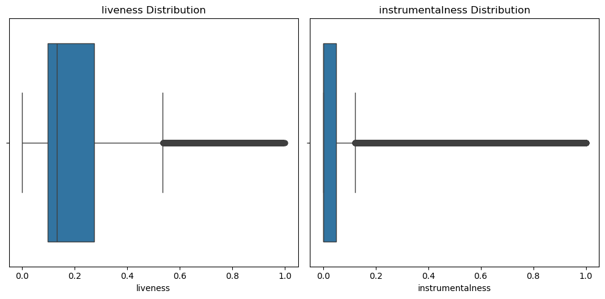

```python
fig,axes=plt.subplots(1,2,figsize=(10,5))
sns.boxplot(ax=axes[0],x=data['liveness'])
axes[0].set_title("liveness Distribution")

sns.boxplot(ax=axes[1],x=data['instrumentalness'])
axes[1].set_title("instrumentalness Distribution")
plt.tight_layout()
plt.show()
```

```python
print("median",data['liveness'].median())
liveness_q1 = data['liveness'].quantile(0.25)
liveness_q3 = data['liveness'].quantile(0.75)
liveness_iqr = liveness_q3 - liveness_q1
print("Q1",liveness_q1)
print("Q2",liveness_q3)
print("IQR",liveness_iqr)
liveness_lower_bound = liveness_q1 - 1.5 * liveness_iqr
liveness_upper_bound = liveness_q3 + 1.5 * liveness_iqr
print("Outlier thresholds:", liveness_lower_bound, "to", liveness_upper_bound)
```

```
median 0.132
Q1 0.098
Q2 0.273
IQR 0.17500000000000002
Outlier thresholds: -0.1645 to 0.5355000000000001
```

```python
liveness_outliers = data[data['liveness'] > liveness_upper_bound]
print("Number of liveness Upper outliers:", len(liveness_outliers))
```

```
Number of liveness Upper outliers: 8610
```

```python
liveness_df=liveness_outliers[[ 'tempo', 'artists', 'track_genre','explicit']]
liveness_df['track_genre'].value_counts()
```

```
track_genre
comedy               739
pagode               463
sertanejo            402
samba                401
sleep                274
                    ...
mandopop              14
acoustic              14
pop                   11
songwriter             9
singer-songwriter      9
Name: count, Length: 114, dtype: int64
```

```python
print("median",data['instrumentalness'].median())
instrumentalness_q1 = data['instrumentalness'].quantile(0.25)
instrumentalness_q3 = data['instrumentalness'].quantile(0.75)
instrumentalness_iqr = instrumentalness_q3 - instrumentalness_q1
print("Q1",instrumentalness_q1)
print("Q2",instrumentalness_q3)
print("IQR",instrumentalness_iqr)
instrumentalness_lower_bound = instrumentalness_q1 - 1.5 * instrumentalness_iqr
instrumentalness_upper_bound = instrumentalness_q3 + 1.5 * instrumentalness_iqr
print("Outlier thresholds:", instrumentalness_lower_bound, "to", instrumentalness_upper_bound)
```

```
median 4.13e-05
Q1 0.0
Q2 0.0487
IQR 0.0487
Outlier thresholds: -0.07305 to 0.12175
```

```python
instrumentalness_outliers = data[data['instrumentalness'] > instrumentalness_upper_bound]
print("Number of instrumentalness Upper outliers:", len(instrumentalness_outliers))
```

```
Number of instrumentalness Upper outliers: 25131
```

```python
instrumentalness_df=instrumentalness_outliers[[ 'tempo', 'artists', 'track_genre','explicit']]
instrumentalness_df['track_genre'].value_counts()
```

```
track_genre
study             968
minimal-techno    941
sleep             866
detroit-techno    864
new-age           857
                 ...
gospel              6
party               4
comedy              3
forro               3
pagode              1
Name: count, Length: 113, dtype: int64
```

## ARTISTS AND THEIR TOP GENRE

```python
artist_genre_counts = data.groupby(['artists', 'track_genre']).size().reset_index(name='track_count')
artist_genre_counts_sorted = artist_genre_counts.sort_values(by='track_count', ascending=False)
artist_genre_counts_sorted.head()            # gives artist name and the count of different genres
```

|  | artists | track_genre | track_count |
| --- | --- | --- | --- |
| 13832 | George Jones | honky-tonk | 260 |
| 40738 | my little airport | cantopop | 171 |
| 35273 | The Beatles | psych-rock | 149 |
| 3726 | BTS | k-pop | 143 |
| 14226 | Glee Cast | club | 139 |

```python
dominant_genre_df=artist_genre_counts_sorted.drop_duplicates(subset=['artists'],keep='first')
dominant_genre_df=dominant_genre_df.rename(columns={'track_genre':'dominant_genre'})
dominant_genre_df.head()#Give artist name and their dominant genre only
```

|  | artists | dominant_genre | track_count |
| --- | --- | --- | --- |
| 13832 | George Jones | honky-tonk | 260 |
| 40738 | my little airport | cantopop | 171 |
| 35273 | The Beatles | psych-rock | 149 |
| 3726 | BTS | k-pop | 143 |
| 14226 | Glee Cast | club | 139 |

```python
genre_artist_data = data[['artists', 'album_name', 'track_name', 'track_genre', 'popularity']]
genre_artist_data = pd.merge(genre_artist_data, dominant_genre_df[['artists', 'dominant_genre']], on='artists', how='left')
genre_artist_data.head()
```

|  | artists | album_name | track_name | track_genre | popularity | dominant_genre |
| --- | --- | --- | --- | --- | --- | --- |
| 0 | Gen Hoshino | Comedy | Comedy | acoustic | 73 | acoustic |
| 1 | Ben Woodward | Ghost (Acoustic) | Ghost - Acoustic | acoustic | 55 | acoustic |
| 2 | Ingrid Michaelson;ZAYN | To Begin Again | To Begin Again | acoustic | 57 | acoustic |
| 3 | Kina Grannis | Crazy Rich Asians (Original Motion Picture Sou... | Can't Help Falling In Love | acoustic | 71 | acoustic |
| 4 | Chord Overstreet | Hold On | Hold On | acoustic | 82 | acoustic |

## Artist's non dominant genre songs and their popularity

```python
non_dominant_songs=genre_artist_data[genre_artist_data['track_genre']!=genre_artist_data['dominant_genre']]
non_dominant_songs
```

|  | artists | album_name | track_name | track_genre | popularity | dominant_genre |
| --- | --- | --- | --- | --- | --- | --- |
| 6 | A Great Big World;Christina Aguilera | Is There Anybody Out There? | Say Something | acoustic | 74 | piano |
| 9 | Ross Copperman | Hunger | Hunger | acoustic | 56 | piano |
| 12 | Dan Berk | Solo | Solo | acoustic | 52 | chill |
| 16 | Andrew Foy;Renee Foy | ily (i love you baby) | ily (i love you baby) | acoustic | 56 | guitar |
| 17 | Andrew Foy;Renee Foy | At My Worst | At My Worst | acoustic | 54 | guitar |
| ... | ... | ... | ... | ... | ... | ... |
| 113003 | Actress | Karma & Desire | Fire and Light | world-music | 57 | club |
| 113054 | Bethel Music;Steffany Gretzinger | You Make Me Brave (Live) | We Dance - Live | world-music | 50 | ambient |
| 113065 | Bethel Music;Steffany Gretzinger | Have It All (Live) | Pieces - Live | world-music | 53 | ambient |
| 113121 | Bethel Music;Paul McClure | We Will Not Be Shaken (Live) | Jesus We Love You - Live | world-music | 53 | ambient |
| 113190 | Bethel Music;Steffany Gretzinger | For the Sake of the World | Closer | world-music | 49 | ambient |

24100 rows × 6 columns

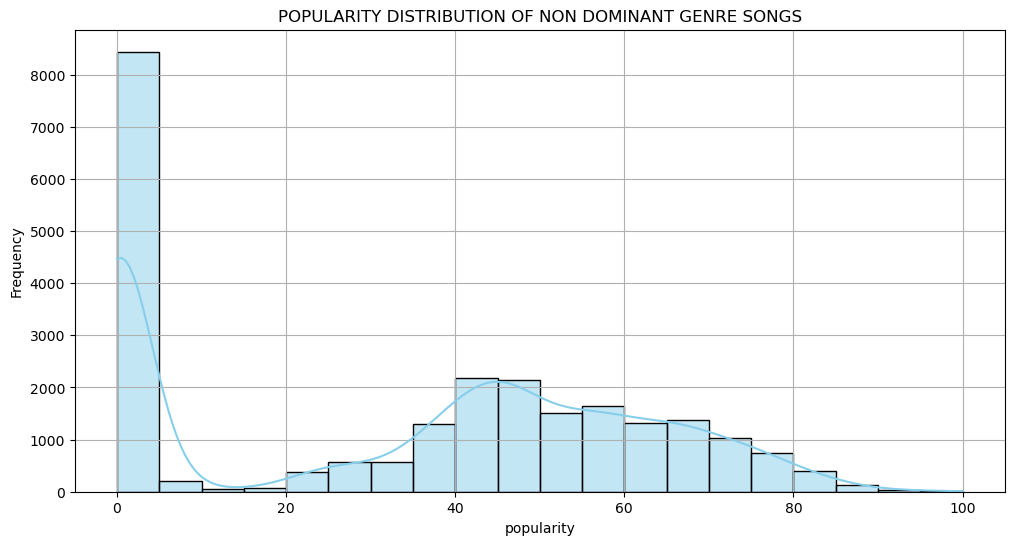

```python
plt.figure(figsize=(12,6))
sns.histplot(data=non_dominant_songs['popularity'],bins=20,kde=True,color='skyblue')
plt.title("POPULARITY DISTRIBUTION OF NON DOMINANT GENRE SONGS")
plt.xlabel('popularity')
plt.ylabel('Frequency')
plt.grid(True)
plt.show()
```

## Artist's dominant genre songs and their popularity

```python
dominant_songs=genre_artist_data[genre_artist_data['track_genre']==genre_artist_data['dominant_genre']]
dominant_songs
```

|  | artists | album_name | track_name | track_genre | popularity | dominant_genre |
| --- | --- | --- | --- | --- | --- | --- |
| 0 | Gen Hoshino | Comedy | Comedy | acoustic | 73 | acoustic |
| 1 | Ben Woodward | Ghost (Acoustic) | Ghost - Acoustic | acoustic | 55 | acoustic |
| 2 | Ingrid Michaelson;ZAYN | To Begin Again | To Begin Again | acoustic | 57 | acoustic |
| 3 | Kina Grannis | Crazy Rich Asians (Original Motion Picture Sou... | Can't Help Falling In Love | acoustic | 71 | acoustic |
| 4 | Chord Overstreet | Hold On | Hold On | acoustic | 82 | acoustic |
| ... | ... | ... | ... | ... | ... | ... |
| 113544 | Rainy Lullaby | #mindfulness - Soft Rain for Mindful Meditatio... | Sleep My Little Boy | world-music | 21 | world-music |
| 113545 | Rainy Lullaby | #mindfulness - Soft Rain for Mindful Meditatio... | Water Into Light | world-music | 22 | world-music |
| 113546 | Cesária Evora | Best Of | Miss Perfumado | world-music | 22 | world-music |
| 113547 | Michael W. Smith | Change Your World | Friends | world-music | 41 | world-music |
| 113548 | Cesária Evora | Miss Perfumado | Barbincor | world-music | 22 | world-music |

89449 rows × 6 columns

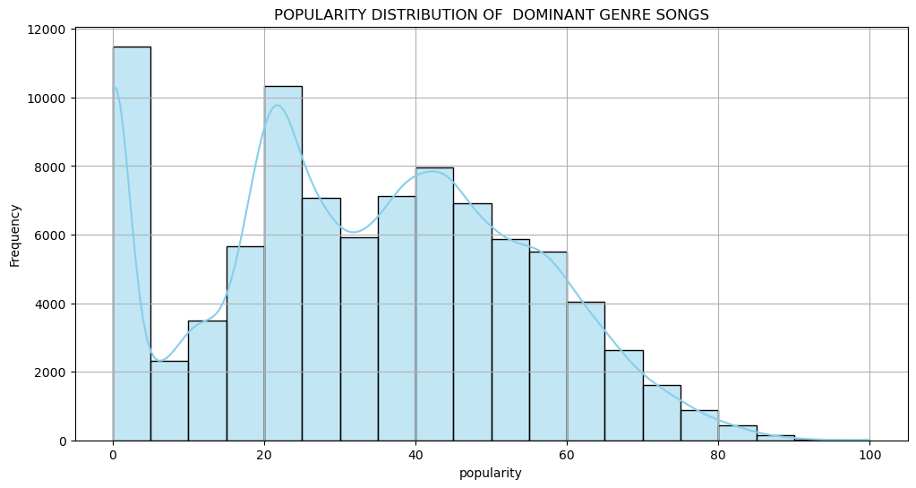

```python
plt.figure(figsize=(12,6))
sns.histplot(data=dominant_songs['popularity'],bins=20,kde=True,color='skyblue')
plt.title("POPULARITY DISTRIBUTION OF  DOMINANT GENRE SONGS")
plt.xlabel('popularity')
plt.ylabel('Frequency')
plt.grid(True)
plt.show()
```

## FINDING TOP ARTISTS IN GIVEN GENRE

```python
(data['track_genre']).unique()
```

```
array(['acoustic', 'afrobeat', 'alt-rock', 'alternative', 'ambient',
       'anime', 'black-metal', 'bluegrass', 'blues', 'brazil',
       'breakbeat', 'british', 'cantopop', 'chicago-house', 'children',
       'chill', 'classical', 'club', 'comedy', 'country', 'dance',
       'dancehall', 'death-metal', 'deep-house', 'detroit-techno',
       'disco', 'disney', 'drum-and-bass', 'dub', 'dubstep', 'edm',
       'electro', 'electronic', 'emo', 'folk', 'forro', 'french', 'funk',
       'garage', 'german', 'gospel', 'goth', 'grindcore', 'groove',
       'grunge', 'guitar', 'happy', 'hard-rock', 'hardcore', 'hardstyle',
       'heavy-metal', 'hip-hop', 'honky-tonk', 'house', 'idm', 'indian',
       'indie-pop', 'indie', 'industrial', 'iranian', 'j-dance', 'j-idol',
       'j-pop', 'j-rock', 'jazz', 'k-pop', 'kids', 'latin', 'latino',
       'malay', 'mandopop', 'metal', 'metalcore', 'minimal-techno', 'mpb',
       'new-age', 'opera', 'pagode', 'party', 'piano', 'pop-film', 'pop',
       'power-pop', 'progressive-house', 'psych-rock', 'punk-rock',
       'punk', 'r-n-b', 'reggae', 'reggaeton', 'rock-n-roll', 'rock',
       'rockabilly', 'romance', 'sad', 'salsa', 'samba', 'sertanejo',
       'show-tunes', 'singer-songwriter', 'ska', 'sleep', 'songwriter',
       'soul', 'spanish', 'study', 'swedish', 'synth-pop', 'tango',
       'techno', 'trance', 'trip-hop', 'turkish', 'world-music'],
      dtype=object)
```

```python
# Step 1: Count how many tracks each artist has in each genre
artist_genre_counts = data.groupby(['artists', 'track_genre']).size().reset_index(name='track_count')

# Step 2: Get the dominant genre per artist
dominant_genres = artist_genre_counts.loc[artist_genre_counts.groupby('artists')['track_count'].idxmax()]
dominant_genres = dominant_genres[['artists', 'track_genre']]
dominant_genres.columns = ['artists', 'dominant_genre']

# Step 3: Merge dominant genre info back to main data
merged_data = data.merge(dominant_genres, on='artists', how='left')

# Step 4: Define function to get top consistent artist for a genre
def get_top_dominant_artist_by_genre(dataframe, input_genre):
    genre_counts = dataframe[dataframe['track_genre'] == input_genre].groupby('artists').size().reset_index(name='track_count')
    genre_counts = genre_counts.merge(dominant_genres, on='artists', how='left')
    consistent_artists = genre_counts[genre_counts['dominant_genre'] == input_genre]

    if consistent_artists.empty:
        return f"No dominant artist found for genre '{input_genre}'."
    else:
        top_artist_row = consistent_artists.sort_values(by='track_count', ascending=False).iloc[0]
        return f"🎤 Top consistent artist in '{input_genre}': {top_artist_row['artists']} with {top_artist_row['track_count']} tracks."

# Step 5: Input from user
user_input_genre = input("Enter a track genre: ")

# Step 6: Call function
print(get_top_dominant_artist_by_genre(merged_data, user_input_genre))
```

```
🎤 Top consistent artist in 'sleep': Weißes Rauschen HD with 47 tracks.
```

## TARGET ENCODING

```python
pip install category_encoders
```

```python
from category_encoders import TargetEncoder
genre_target_mean = data.groupby('track_genre')['popularity'].mean()
data['track_genre_encoded'] = data['track_genre'].map(genre_target_mean)
```

```python
artist_target_mean = data.groupby('artists')['popularity'].mean()
data['artist_encoded'] = data['artists'].map(artist_target_mean)
```

## Feature selection

```python
features= ['artist_encoded','duration_ms','explicit','energy','loudness','mode','speechiness','acousticness','instrumentalness','liveness','valence','tempo','time_signature','track_genre_encoded']
```

## Scaling

since most of the data are between o and 1. using minmax scaler

```python
from sklearn.preprocessing import MinMaxScaler
scaler = MinMaxScaler()
columns_to_scale = ['duration_ms', 'loudness', 'tempo']
data[columns_to_scale] = scaler.fit_transform(data[columns_to_scale])
```

## Considerig Skewness

```python
from sklearn.preprocessing import PowerTransformer
data_model = data.copy()
pt = PowerTransformer(method='yeo-johnson')
data_model['popularity_trans'] = pt.fit_transform(data_model[['popularity']])
```

## Train and Test Split

```python
from sklearn.model_selection import train_test_split
X=data[features]
y=data['popularity']
X_train, X_test, y_train, y_test = train_test_split(X, y, test_size=0.2, random_state=42)
```

```python
print(X_train.columns)
print(X_test.columns)
```

```
Index(['artist_encoded', 'duration_ms', 'explicit', 'energy', 'loudness',
       'mode', 'speechiness', 'acousticness', 'instrumentalness', 'liveness',
       'valence', 'tempo', 'time_signature', 'track_genre_encoded'],
      dtype='object')
Index(['artist_encoded', 'duration_ms', 'explicit', 'energy', 'loudness',
       'mode', 'speechiness', 'acousticness', 'instrumentalness', 'liveness',
       'valence', 'tempo', 'time_signature', 'track_genre_encoded'],
      dtype='object')
```

## LINEAR REGRESSION

```python
from sklearn.linear_model import LinearRegression
from sklearn.metrics import mean_squared_error, r2_score

model = LinearRegression()
model.fit(X_train, y_train)

y_pred = model.predict(X_test)
mse = mean_squared_error(y_test, y_pred)
r2 = r2_score(y_test, y_pred)

print(f"Mean Squared Error: {mse}")
print(f"R-squared: {r2}")
```

```
Mean Squared Error: 133.6093202825091
R-squared: 0.7336410410715279
```

```python
coefficients = model.coef_
intercept = model.intercept_
equation = f"y = {intercept:.2f} "
for feature, coef in zip(X.columns, coefficients):
    equation += f"+ ({coef:.2f} * {feature}) "
print(f"Regression Equation: {equation}")
```

[output not shown]

Linear Regression Models: Given that there is no strong correlation between most features and popularity, a simple linear regression might not perform well.

### MODELLING

Because the correlations are weak or non-linear, models like Random Forests or XGBoost might perform better. They don’t rely on strong linear relationships and can capture more complex patterns.

## RANDOM FOREST

```python
from sklearn.ensemble import RandomForestRegressor
from sklearn.metrics import mean_squared_error, r2_score
```

#### TRY1

```python
rf1_model = RandomForestRegressor(n_estimators=100,random_state=42,max_depth=10)
```

```python
rf1_model.fit(X_train, y_train)
```

```
RandomForestRegressor(max_depth=10, random_state=42)
```

```python
y_pred1 = rf1_model.predict(X_test)
mse1 = mean_squared_error(y_test, y_pred1)
rsq_1 = r2_score(y_test, y_pred1)
print(f"Mean Squared Error: {mse1}")
print(f"R-squared: {rsq_1}")
```

```
Mean Squared Error: 124.3965395848191
R-squared: 0.75200732472812
```

#### TRY2

```python
rf2_model = RandomForestRegressor(n_estimators=200,random_state=42,max_depth=10)
```

```python
rf2_model.fit(X_train, y_train)
```

```
RandomForestRegressor(max_depth=10, n_estimators=200, random_state=42)
```

```python
y_pred2 = rf2_model.predict(X_test)
mse2 = mean_squared_error(y_test, y_pred2)
rsq_2 = r2_score(y_test, y_pred2)
print(f"Mean Squared Error: {mse2}")
print(f"R-squared: {rsq_2}")
```

```
Mean Squared Error: 124.34762080822802
R-squared: 0.7521048475235157
```

#### TRY3

```python
rf3_model = RandomForestRegressor(n_estimators=100,max_depth=None,random_state=42,n_jobs=-1)
```

```python
rf3_model.fit(X_train, y_train)
```

```
RandomForestRegressor(n_jobs=-1, random_state=42)
```

```python
y_pred3 = rf3_model.predict(X_test)
mse3 = mean_squared_error(y_test, y_pred3)
rsq_3 = r2_score(y_test, y_pred3)
print(f"Mean Squared Error: {mse3}")
print(f"R-squared: {rsq_3}")
```

```
Mean Squared Error: 111.84251143574343
R-squared: 0.7770346047193369
```

#### TRY4

```python
rf4_model = RandomForestRegressor(n_estimators=100,max_depth=20,random_state=42,n_jobs=-1)
```

```python
rf4_model.fit(X_train, y_train)
```

```
RandomForestRegressor(max_depth=20, n_jobs=-1, random_state=42)
```

```python
y_pred4 = rf4_model.predict(X_test)
mse4 = mean_squared_error(y_test, y_pred4)
rsq_4 = r2_score(y_test, y_pred4)
print(f"Mean Squared Error: {mse4}")
print(f"R-squared: {rsq_4}")
```

```
Mean Squared Error: 110.95402879472887
R-squared: 0.778805853242915
```

#### TRY5

```python
rf5_model = RandomForestRegressor(n_estimators=100,max_depth=25,random_state=42,n_jobs=-1)
```

```python
rf5_model.fit(X_train, y_train)
```

```
RandomForestRegressor(max_depth=25, n_jobs=-1, random_state=42)
```

```python
y_pred5 = rf5_model.predict(X_test)
mse5 = mean_squared_error(y_test, y_pred5)
rsq_5 = r2_score(y_test, y_pred5)
print(f"Mean Squared Error: {mse5}")
print(f"R-squared: {rsq_5}")
```

```
Mean Squared Error: 111.06810993619774
R-squared: 0.7785784249915716
```

#### TRY6

```python
rf6_model = RandomForestRegressor(n_estimators=100,max_depth=30,random_state=42,n_jobs=-1)
```

```python
rf6_model.fit(X_train, y_train)
```

```
RandomForestRegressor(max_depth=30, n_jobs=-1, random_state=42)
```

```python
y_pred6 = rf6_model.predict(X_test)
mse6 = mean_squared_error(y_test, y_pred6)
rsq_6 = r2_score(y_test, y_pred6)
print(f"Mean Squared Error: {mse6}")
print(f"R-squared: {rsq_6}")
```

```
Mean Squared Error: 111.66278705544258
R-squared: 0.777392897080452
```

#### TRY 7

```python
rf7_model = RandomForestRegressor(n_estimators=100,max_depth=40,random_state=42,n_jobs=-1)
```

```python
rf7_model.fit(X_train, y_train)
```

```
RandomForestRegressor(max_depth=40, n_jobs=-1, random_state=42)
```

```python
y_pred7 = rf7_model.predict(X_test)
mse7 = mean_squared_error(y_test, y_pred7)
rsq_7 = r2_score(y_test, y_pred7)
print(f"Mean Squared Error: {mse7}")
print(f"R-squared: {rsq_7}")
```

```
Mean Squared Error: 111.85016461385263
R-squared: 0.7770193476059158
```

## XGBoost

```python
pip install xgboost scikit-learn
```

```python
from xgboost import XGBRegressor
```

#### try1

```python
xg_model1 = XGBRegressor(n_estimators=100, learning_rate=0.1, random_state=42)
```

```python
xg_model1.fit(X_train, y_train)
```

```
XGBRegressor(base_score=None, booster=None, callbacks=None,
             colsample_bylevel=None, colsample_bynode=None,
             colsample_bytree=None, device=None, early_stopping_rounds=None,
             enable_categorical=False, eval_metric=None, feature_types=None,
             feature_weights=None, gamma=None, grow_policy=None,
             importance_type=None, interaction_constraints=None,
             learning_rate=0.1, max_bin=None, max_cat_threshold=None,
             max_cat_to_onehot=None, max_delta_step=None, max_depth=None,
             max_leaves=None, min_child_weight=None, missing=nan,
             monotone_constraints=None, multi_strategy=None, n_estimators=100,
             n_jobs=None, num_parallel_tree=None, ...)
```

```python
y_pred_xg1 = xg_model1.predict(X_test)
mse_xg1 =mean_squared_error(y_test, y_pred_xg1)
r2_xg1 = r2_score(y_test, y_pred_xg1)
print(f"Mean Squared Error: {mse_xg1}")
print(f"R-squared: {r2_xg1}")
```

```
Mean Squared Error: 126.67769622802734
R-squared: 0.7474597096443176
```

#### try2

```python
xg2_model = XGBRegressor(
    n_estimators=100,
    learning_rate=0.1,
    reg_alpha=0.1,
    reg_lambda=1.0,
    random_state=42
)
```

```python
xg2_model.fit(X_train, y_train)
```

```
XGBRegressor(base_score=None, booster=None, callbacks=None,
             colsample_bylevel=None, colsample_bynode=None,
             colsample_bytree=None, device=None, early_stopping_rounds=None,
             enable_categorical=False, eval_metric=None, feature_types=None,
             feature_weights=None, gamma=None, grow_policy=None,
             importance_type=None, interaction_constraints=None,
             learning_rate=0.1, max_bin=None, max_cat_threshold=None,
             max_cat_to_onehot=None, max_delta_step=None, max_depth=None,
             max_leaves=None, min_child_weight=None, missing=nan,
             monotone_constraints=None, multi_strategy=None, n_estimators=100,
             n_jobs=None, num_parallel_tree=None, ...)
```

```python
y_pred_xg2 = xg2_model.predict(X_test)
mse_xg2 =mean_squared_error(y_test, y_pred_xg2)
r2_xg2 = r2_score(y_test, y_pred_xg2)
print(f"Mean Squared Error: {mse_xg2}")
print(f"R-squared: {r2_xg2}")
```

```
Mean Squared Error: 126.56532287597656
R-squared: 0.7476837635040283
```

#### try3

```python
xg3_model = XGBRegressor(
    n_estimators=100,
    learning_rate=0.1,
    max_depth=5,         # Try 4 to 6
    reg_alpha=0.1,
    reg_lambda=1.0,
    random_state=42
)
```

```python
xg3_model.fit(X_train, y_train)
```

```
XGBRegressor(base_score=None, booster=None, callbacks=None,
             colsample_bylevel=None, colsample_bynode=None,
             colsample_bytree=None, device=None, early_stopping_rounds=None,
             enable_categorical=False, eval_metric=None, feature_types=None,
             feature_weights=None, gamma=None, grow_policy=None,
             importance_type=None, interaction_constraints=None,
             learning_rate=0.1, max_bin=None, max_cat_threshold=None,
             max_cat_to_onehot=None, max_delta_step=None, max_depth=5,
             max_leaves=None, min_child_weight=None, missing=nan,
             monotone_constraints=None, multi_strategy=None, n_estimators=100,
             n_jobs=None, num_parallel_tree=None, ...)
```

```python
y_pred_xg3 = xg3_model.predict(X_test)
mse_xg3 =mean_squared_error(y_test, y_pred_xg3)
r2_xg3 = r2_score(y_test, y_pred_xg3)
print(f"Mean Squared Error: {mse_xg3}")
print(f"R-squared: {r2_xg2}")
```

```
Mean Squared Error: 129.23171997070312
R-squared: 0.7476837635040283
```

## GradientBoostingRegressor

#### try1

```python
from sklearn.ensemble import GradientBoostingRegressor
```

```python
gb1_model = GradientBoostingRegressor(n_estimators=100, learning_rate=0.1, random_state=42)
gb1_model.fit(X_train, y_train)
```

```
GradientBoostingRegressor(random_state=42)
```

```python
y_pred_gb1 = gb1_model.predict(X_test)
```

```python
print("MSE:", mean_squared_error(y_test, y_pred_gb1))
print("R²:", r2_score(y_test, y_pred_gb1))
```

```
MSE: 132.43596703600215
R²: 0.7359801978648871
```

#### try2

```python
gb2_model = GradientBoostingRegressor(
    n_estimators=200,        # Increase the number of trees
    learning_rate=0.05,      # Lower learning rate for finer updates
    random_state=42
)
```

```python
gb2_model.fit(X_train, y_train)
```

```
GradientBoostingRegressor(learning_rate=0.05, n_estimators=200, random_state=42)
```

```python
y_pred_gb2 = gb2_model.predict(X_test)
```

```python
print("MSE:", mean_squared_error(y_test, y_pred_gb2))
print("R²:", r2_score(y_test, y_pred_gb2))
```

```
MSE: 132.38762283939417
R²: 0.736076575197333
```

#### try3

```python
gb3_model = GradientBoostingRegressor(
    n_estimators=200,
    learning_rate=0.05,
    max_depth=5,             # Control depth of trees
    random_state=42
)
```

```python
gb3_model.fit(X_train, y_train)
```

```
GradientBoostingRegressor(learning_rate=0.05, max_depth=5, n_estimators=200,
                          random_state=42)
```

```python
y_pred_gb3 = gb3_model.predict(X_test)
```

```python
print("MSE:", mean_squared_error(y_test,y_pred_gb3))
print("R²:", r2_score(y_test,y_pred_gb3))
```

```
MSE: 128.37640972695334
R²: 0.7440731920980915
```

#### try4

```python
gb4_model = GradientBoostingRegressor(
    n_estimators=200,
    learning_rate=0.05,
    max_depth=5,
    subsample=0.8,
    min_samples_split=10,     # Higher value for more conservative splits
    random_state=42
)
```

```python
gb4_model.fit(X_train, y_train)
```

```
GradientBoostingRegressor(learning_rate=0.05, max_depth=5, min_samples_split=10,
                          n_estimators=200, random_state=42, subsample=0.8)
```

```python
y_pred_gb4 = gb4_model.predict(X_test)
```

```python
print("MSE:", mean_squared_error(y_test, y_pred_gb4))
print("R²:", r2_score(y_test, y_pred_gb4))
```

```
MSE: 128.24144831686942
R²: 0.7443422465368796
```

## LightGBM (Light Gradient Boosting)

```python
import lightgbm as lgb
```

#### try1

```python
lgb1_model = lgb.LGBMRegressor(n_estimators=100, learning_rate=0.1, random_state=42)
```

```python
lgb1_model.fit(X_train, y_train)
```

```
[LightGBM] [Info] Auto-choosing col-wise multi-threading, the overhead of testing was 0.015673 seconds.
You can set `force_col_wise=true` to remove the overhead.
[LightGBM] [Info] Total Bins 2673
[LightGBM] [Info] Number of data points in the train set: 90839, number of used features: 14
[LightGBM] [Info] Start training from score 33.339821
```

```
LGBMRegressor(random_state=42)
```

```python
y_pred_lgb1 = lgb1_model.predict(X_test)
```

```python
print("MSE:", mean_squared_error(y_test, y_pred_lgb1))
print("R²:", r2_score(y_test, y_pred_lgb1))
```

```
MSE: 126.78176041861194
R²: 0.7472522302724324
```

#### try2

```python
lgb2_model = lgb.LGBMRegressor(
    n_estimators=200,         # Increase trees
    learning_rate=0.05,       # Lower learning rate
    random_state=42
)
```

```python
lgb2_model.fit(X_train, y_train)
```

```
[LightGBM] [Info] Auto-choosing col-wise multi-threading, the overhead of testing was 0.011667 seconds.
You can set `force_col_wise=true` to remove the overhead.
[LightGBM] [Info] Total Bins 2673
[LightGBM] [Info] Number of data points in the train set: 90839, number of used features: 14
[LightGBM] [Info] Start training from score 33.339821
```

```
LGBMRegressor(learning_rate=0.05, n_estimators=200, random_state=42)
```

```python
y_pred_lgb2 = lgb2_model.predict(X_test)
print("MSE:", mean_squared_error(y_test, y_pred_lgb2))
print("R²:", r2_score(y_test, y_pred_lgb2))
```

```
MSE: 126.29671830218035
R²: 0.748219193601757
```

#### try3

```python
lgb3_model = lgb.LGBMRegressor(
    n_estimators=200,
    learning_rate=0.05,
    max_depth=7,              # Control tree depth
    num_leaves=31,            # Control tree complexity
    random_state=42
)
```

```python
lgb3_model.fit(X_train, y_train)
```

```
[LightGBM] [Info] Auto-choosing col-wise multi-threading, the overhead of testing was 0.013056 seconds.
You can set `force_col_wise=true` to remove the overhead.
[LightGBM] [Info] Total Bins 2673
[LightGBM] [Info] Number of data points in the train set: 90839, number of used features: 14
[LightGBM] [Info] Start training from score 33.339821
```

```
LGBMRegressor(learning_rate=0.05, max_depth=7, n_estimators=200,
              random_state=42)
```

```python
y_pred_lgb3 = lgb3_model.predict(X_test)
print("MSE:", mean_squared_error(y_test, y_pred_lgb3))
print("R²:", r2_score(y_test, y_pred_lgb3))
```

```
MSE: 127.28320213785989
R²: 0.7462525732573395
```

#### try4

```python
lgb4_model = lgb.LGBMRegressor(
    n_estimators=200,
    learning_rate=0.05,
    max_depth=7,
    num_leaves=31,
    subsample=0.8,            # Use only 80% of samples per tree
    random_state=42
)
```

```python
lgb4_model.fit(X_train, y_train)
```

```
[LightGBM] [Info] Auto-choosing col-wise multi-threading, the overhead of testing was 0.012781 seconds.
You can set `force_col_wise=true` to remove the overhead.
[LightGBM] [Info] Total Bins 2673
[LightGBM] [Info] Number of data points in the train set: 90839, number of used features: 14
[LightGBM] [Info] Start training from score 33.339821
```

```
LGBMRegressor(learning_rate=0.05, max_depth=7, n_estimators=200,
              random_state=42, subsample=0.8)
```

```python
y_pred_lgb4 = lgb4_model.predict(X_test)
print("MSE:", mean_squared_error(y_test, y_pred_lgb4))
print("R²:", r2_score(y_test, y_pred_lgb4))
```

```
MSE: 127.28320213785989
R²: 0.7462525732573395
```

## K-Nearest Neighbors (KNN)

```python
from sklearn.neighbors import KNeighborsRegressor
```

#### try1

```python
knn1_model = KNeighborsRegressor(n_neighbors=5)
```

```python
knn1_model.fit(X_train, y_train)
```

```
KNeighborsRegressor()
```

```python
y_knn1_pred = knn1_model.predict(X_test)
```

```python
print("MSE:", mean_squared_error(y_test, y_knn1_pred))
print("R²:", r2_score(y_test, y_knn1_pred))
```

```
MSE: 152.7990154117129
R²: 0.6953851229517303
```

#### try2

```python
from sklearn.preprocessing import StandardScaler
scaler = StandardScaler()
X_scaled = scaler.fit_transform(X)
```

```python
knn2_model =KNeighborsRegressor(n_neighbors=5, weights='distance')
knn2_model.fit(X_train, y_train)
```

```
KNeighborsRegressor(weights='distance')
```

```python
y_knn2_pred= knn2_model.predict(X_test)
```

```python
print("MSE:", mean_squared_error(y_test, y_knn2_pred))
print("R²:", r2_score(y_test, y_knn2_pred))
```

```
MSE: 168.59725317462124
R²: 0.6638902979310268
```

## INVERSE TRANSFORM

```python
import pandas as pd
y_pred4_df = pd.DataFrame(y_pred4, columns=['popularity'])
y_pred4_original = pt.inverse_transform(y_pred4_df).flatten()
y_test_original = pt.inverse_transform(pd.DataFrame(y_test, columns=['popularity'])).flatten()
```

## FEATURE IMPORTANCE

```python
importances = rf4_model.feature_importances_
feature_names = X_train.columns
feature_names
```

```
Index(['artist_encoded', 'duration_ms', 'explicit', 'energy', 'loudness',
       'mode', 'speechiness', 'acousticness', 'instrumentalness', 'liveness',
       'valence', 'tempo', 'time_signature', 'track_genre_encoded'],
      dtype='object')
```

```python
feature_importance_df = pd.DataFrame({
    'Feature': feature_names,
    'Importance': importances})
feature_importance_df
```

|  | Feature | Importance |
| --- | --- | --- |
| 0 | artist_encoded | 0.805859 |
| 1 | duration_ms | 0.015925 |
| 2 | explicit | 0.001384 |
| 3 | energy | 0.015566 |
| 4 | loudness | 0.018424 |
| 5 | mode | 0.001631 |
| 6 | speechiness | 0.020788 |
| 7 | acousticness | 0.019376 |
| 8 | instrumentalness | 0.013281 |
| 9 | liveness | 0.017167 |
| 10 | valence | 0.019236 |
| 11 | tempo | 0.023522 |
| 12 | time_signature | 0.001333 |
| 13 | track_genre_encoded | 0.026508 |

```python
feature_importance_df = feature_importance_df.sort_values(by='Importance', ascending=False)
feature_importance_df
```

|  | Feature | Importance |
| --- | --- | --- |
| 0 | artist_encoded | 0.805859 |
| 13 | track_genre_encoded | 0.026508 |
| 11 | tempo | 0.023522 |
| 6 | speechiness | 0.020788 |
| 7 | acousticness | 0.019376 |
| 10 | valence | 0.019236 |
| 4 | loudness | 0.018424 |
| 9 | liveness | 0.017167 |
| 1 | duration_ms | 0.015925 |
| 3 | energy | 0.015566 |
| 8 | instrumentalness | 0.013281 |
| 5 | mode | 0.001631 |
| 2 | explicit | 0.001384 |
| 12 | time_signature | 0.001333 |

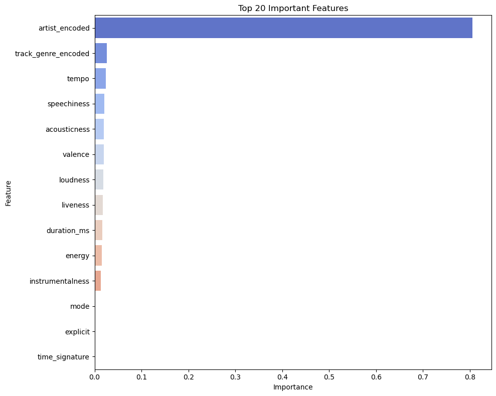

```python
top_n = 20  # you can change this number to 30 or 25 if you want
top_features = feature_importance_df.head(top_n)

# Plotting
plt.figure(figsize=(10, 8))
sns.barplot(x='Importance', y='Feature', data=top_features,dodge=False,legend=False,palette='coolwarm')
plt.title(f'Top {top_n} Important Features')
plt.xlabel('Importance')
plt.ylabel('Feature')
plt.tight_layout()
plt.show()
```

#### **inference** :Artist" plays the major role in predicting popularity

## Testing without artist feature

```python
X_train_new = X_train.drop(columns=['artist_encoded'])
X_test_new = X_test.drop(columns=['artist_encoded'])
```

```python
rf_model_new = RandomForestRegressor(random_state=42,n_estimators=100,n_jobs=-1,max_depth=40)
```

```python
rf_model_new.fit(X_train_new, y_train)
```

```
RandomForestRegressor(max_depth=40, n_jobs=-1, random_state=42)
```

```python
y_pred_new = rf_model_new.predict(X_test_new)
y_pred_new
```

```
array([45.92661757, 39.56      , 20.48901961, ..., 13.62333333,
       41.86366667, 38.052     ])
```

```python
mse_new=mean_squared_error(y_test,y_pred_new)
r2_new=r2_score(y_test,y_pred_new)
print(f"MSE withour artists:{mse_new}")
print(f"R square value without artists{r2_new}")
```

```
MSE withour artists:262.98621248493504
R square value without artists0.47571970561697874
```

#### **inference** :Artist was carrying a lot of info about popularity after removing artist column .MSE increased R2 decreased.Model accuracy dropped significantly

## ACTUAL VS PREDICTED PLOT

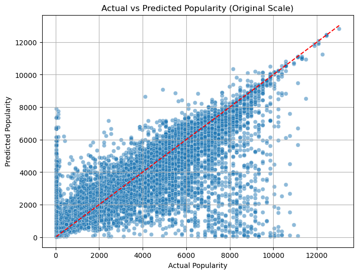

```python
min_val = min(y_test_original.min(), y_pred4_original.min())
max_val = max(y_test_original.max(), y_pred4_original.max())

plt.figure(figsize=(8, 6))
sns.scatterplot(x=y_test_original, y=y_pred4_original, alpha=0.5)

# Red reference line: y = x
plt.plot([min_val, max_val], [min_val, max_val], color='red', linestyle='--')

plt.xlabel('Actual Popularity')
plt.ylabel('Predicted Popularity')
plt.title('Actual vs Predicted Popularity (Original Scale)')
plt.grid(True)
plt.show()
```

#### **inference** :The predicted popularity shows a positive correlation with actual values, but noticeable deviations and spread indicate the model is not perfectly accurate and could be improved.

## RESIDUAL PLOT

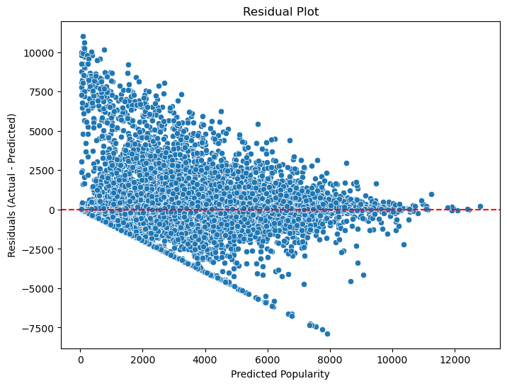

```python
residuals = y_test_original - y_pred4_original
plt.figure(figsize=(8,6))
sns.scatterplot(x=y_pred4_original, y=residuals)
plt.axhline(0, color='red', linestyle='--')
plt.xlabel('Predicted Popularity')
plt.ylabel('Residuals (Actual - Predicted)')
plt.title('Residual Plot')
plt.show()
```

#### **inference** :presence of heteroscedasticity

## CV score

```python
from sklearn.model_selection import cross_val_score
scores = cross_val_score(rf4_model, X, y, cv=5, scoring='r2')
print("Cross-validated R² scores:", scores)
print("Average R²:",scores.mean())
```

```
Cross-validated R² scores: [0.74575258 0.76987561 0.79535485 0.71940942 0.73540915]
Average R²: 0.7531603217468539
```

#### **inference** :The model achieved a consistent R² across all folds, with an average score of 0.75, indicating good predictive performance and generalizability on unseen data.

## Visualize the scores

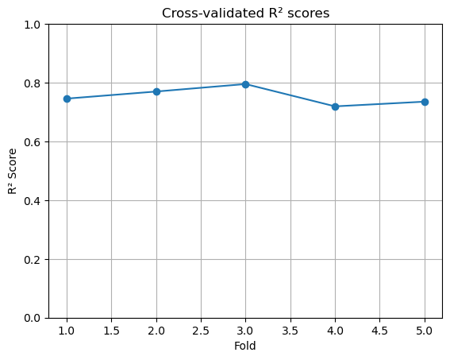

```python
import matplotlib.pyplot as plt

plt.plot(range(1, 6), scores, marker='o')
plt.title("Cross-validated R² scores")
plt.xlabel("Fold")
plt.ylabel("R² Score")
plt.ylim(0, 1)
plt.grid(True)
plt.show()
```

```python
for col in X_const.select_dtypes(include=['bool']).columns:
    X_const[col] = X_const[col].astype(int)
```

## Train on the full dataset

```python
rf4_model.fit(X, y)
```

```
RandomForestRegressor(max_depth=20, n_jobs=-1, random_state=42)
```

## SAVE THE MODEL

```python
import joblib
joblib.dump(rf4_model, 'rf4_model.pkl')
```

```
['rf4_model.pkl']
```

```python
joblib.dump(genre_target_mean, 'artist_target_encoding.pkl')
```

```
['artist_target_encoding.pkl']
```